# Assignment 2

2025-09-21

```r
# Load required libraries
library(car)
library(dplyr)
library(tidyverse)
library(knitr)
library(kableExtra)
library(gridExtra)
getwd()
```

```
## [1] "/Users/nico/Documents/EUR/Marketing/Assignment/Strategic-Marketing/Assignments"
```

```r
rm(list=ls())
```

# Question 1 (1 point)

Run a single logistic regression model on the full sample of customers. The logistic regression model should predict the probability that a customer churns by using the following variables: monthly charges, total charges, gender, senior citizen status, partner, dependents, tenure, phone service, streaming movies, contract type, paperless billing, and payment method. Make sure to convert all categorical variables to factors for appropriate analysis. Note that some variables are already excluded to avoid multicollinearity. Report only the variance inflation factors (VIFs) for each variable. What do you conclude? (No need to report the final model output.)

```r
stopifnot(file.exists("Telco.csv"))
data <- readr::read_csv("Telco.csv", show_col_types = FALSE)
```

```r
# Convert relaveant cols to as.factor
# categorical_vars <- c("gender", "SeniorCitizen", "Partner", "Dependents",
#                      "PhoneService", "StreamingMovies", "Contract",
#                      "PaperlessBilling", "PaymentMethod", "Churn")
#
# data[categorical_vars] <- lapply(data[categorical_vars], as.factor)

data$Churn = as.factor(data$Churn)
data[sapply(data, is.character)] <- lapply(data[sapply(data, is.character)], as.factor)
```

```r
# Build the logistic regression model
model <- glm(Churn ~ MonthlyCharges + TotalCharges + gender + SeniorCitizen +
             Partner + Dependents + tenure + PhoneService + StreamingMovies +
             Contract + PaperlessBilling + PaymentMethod,
             data = data,
             family = "binomial")

summary(model)
```

```
##
## Call:
## glm(formula = Churn ~ MonthlyCharges + TotalCharges + gender +
##     SeniorCitizen + Partner + Dependents + tenure + PhoneService +
##     StreamingMovies + Contract + PaperlessBilling + PaymentMethod,
##     family = "binomial", data = data)
##
## Coefficients:
##                                        Estimate Std. Error z value Pr(>|z|)
## (Intercept)                          -8.305e-01  1.985e-01  -4.185 2.86e-05 ***
## MonthlyCharges                        2.230e-02  3.223e-03   6.920 4.52e-12 ***
## TotalCharges                          2.759e-04  7.027e-05   3.926 8.64e-05 ***
## genderMale                           -9.370e-03  6.391e-02  -0.147 0.883434
## SeniorCitizen                         3.136e-01  8.291e-02   3.783 0.000155 ***
## PartnerYes                            7.282e-03  7.667e-02   0.095 0.924326
## DependentsYes                        -1.919e-01  8.847e-02  -2.169 0.030074 *
## tenure                               -6.025e-02  6.209e-03  -9.704  < 2e-16 ***
## PhoneServiceYes                      -8.328e-01  1.539e-01  -5.411 6.26e-08 ***
## StreamingMoviesNo internet service    3.188e-02  1.804e-01   0.177 0.859715
## StreamingMoviesYes                   -2.011e-02  8.699e-02  -0.231 0.817156
## ContractOne year                     -8.606e-01  1.046e-01  -8.225  < 2e-16 ***
## ContractTwo year                     -1.720e+00  1.731e-01  -9.937  < 2e-16 ***
## PaperlessBillingYes                   4.018e-01  7.309e-02   5.497 3.87e-08 ***
## PaymentMethodCredit card (automatic) -9.920e-02  1.127e-01  -0.880 0.378657
## PaymentMethodElectronic check         3.907e-01  9.298e-02   4.202 2.65e-05 ***
## PaymentMethodMailed check            -1.061e-01  1.129e-01  -0.939 0.347505
## ---
## Signif. codes:  0 '***' 0.001 '**' 0.01 '*' 0.05 '.' 0.1 ' ' 1
##
## (Dispersion parameter for binomial family taken to be 1)
##
##     Null deviance: 8143.4  on 7031  degrees of freedom
## Residual deviance: 5948.6  on 7015  degrees of freedom
##   (11 observations deleted due to missingness)
## AIC: 5982.6
##
## Number of Fisher Scoring iterations: 6
```

```r
# Calculate VIF values
vif_values <- vif(model)

vif_values
```

```
##                       GVIF Df GVIF^(1/(2*Df))
## MonthlyCharges    7.182394  1        2.679999
## TotalCharges     20.346846  1        4.510748
## gender            1.001876  1        1.000937
## SeniorCitizen     1.119678  1        1.058148
## Partner           1.371193  1        1.170980
## Dependents        1.280484  1        1.131585
## tenure           15.836108  1        3.979461
## PhoneService      2.041302  1        1.428741
## StreamingMovies   4.177419  2        1.429641
## Contract          1.498670  2        1.106437
## PaperlessBilling  1.113783  1        1.055359
## PaymentMethod     1.338570  3        1.049801
```

# Quesiton 2 (3 points)

Exclude total charges from the model in Question 1 and re-run the logistic regression. Present the final model output. Select three significant variables and interpret their coefficients (i.e., sign, significance, exact relationship between independent and dependent variables).

```r
model_2 <-  glm(Churn ~ MonthlyCharges + gender + SeniorCitizen +
             Partner + Dependents + tenure + PhoneService + StreamingMovies +
             Contract + PaperlessBilling + PaymentMethod,
             data = data,
             family = "binomial")

summary(model_2)
```

```
##
## Call:
## glm(formula = Churn ~ MonthlyCharges + gender + SeniorCitizen +
##     Partner + Dependents + tenure + PhoneService + StreamingMovies +
##     Contract + PaperlessBilling + PaymentMethod, family = "binomial",
##     data = data)
##
## Coefficients:
##                                       Estimate Std. Error z value Pr(>|z|)
## (Intercept)                          -1.292560   0.160670  -8.045 8.64e-16 ***
## MonthlyCharges                        0.028676   0.002778  10.323  < 2e-16 ***
## genderMale                           -0.007845   0.063983  -0.123 0.902420
## SeniorCitizen                         0.312839   0.083232   3.759 0.000171 ***
## PartnerYes                            0.004988   0.076607   0.065 0.948085
## DependentsYes                        -0.207773   0.088416  -2.350 0.018775 *
## tenure                               -0.037685   0.002229 -16.905  < 2e-16 ***
## PhoneServiceYes                      -0.844717   0.151589  -5.572 2.51e-08 ***
## StreamingMoviesNo internet service    0.186814   0.174788   1.069 0.285158
## StreamingMoviesYes                   -0.011977   0.086656  -0.138 0.890068
## ContractOne year                     -0.862362   0.103755  -8.312  < 2e-16 ***
## ContractTwo year                     -1.699475   0.170228  -9.984  < 2e-16 ***
## PaperlessBillingYes                   0.396008   0.072910   5.431 5.59e-08 ***
## PaymentMethodCredit card (automatic) -0.095402   0.112678  -0.847 0.397172
## PaymentMethodElectronic check         0.398605   0.093033   4.285 1.83e-05 ***
## PaymentMethodMailed check            -0.060927   0.111892  -0.545 0.586086
## ---
## Signif. codes:  0 '***' 0.001 '**' 0.01 '*' 0.05 '.' 0.1 ' ' 1
##
## (Dispersion parameter for binomial family taken to be 1)
##
##     Null deviance: 8150.1  on 7042  degrees of freedom
## Residual deviance: 5966.9  on 7027  degrees of freedom
## AIC: 5998.9
##
## Number of Fisher Scoring iterations: 6
```

# Question 3 (3 points)

Provide two actionable recommendations in light of the model results of Question 2 (i.e., the one excluding total charges). Provide brief justification for each recommendation.

# Question 4 (1 points)

Use the model of Question 2 (i.e., the one excluding total charges). Generate and provide two lists: one with the 10 customers having the highest predicted churn probabilities and another with the 10 customers having the lowest predicted churn probabilities. Each list should include the customer ID, the predicted churn probability, and the actual churn outcome. Present these results in a well-organized table.

```r
# We add the predicted variable to the data set.

data <- data %>%
  mutate(Prediction = predict(model_2, type = 'response'))

colnames(data)
```

```
##  [1] "customerID"       "gender"           "SeniorCitizen"    "Partner"
##  [5] "Dependents"       "tenure"           "PhoneService"     "MultipleLines"
##  [9] "InternetService"  "OnlineSecurity"   "OnlineBackup"     "DeviceProtection"
## [13] "TechSupport"      "StreamingTV"      "StreamingMovies"  "Contract"
## [17] "PaperlessBilling" "PaymentMethod"    "MonthlyCharges"   "TotalCharges"
## [21] "Churn"            "Prediction"
```

```r
top10 <- data %>%
  dplyr :: select(customerID, Churn, Prediction) %>%
  arrange(desc(Prediction)) %>%
  head(10)


bottom10 <- data %>%
  dplyr ::select(customerID, Churn, Prediction) %>%
  arrange(Prediction) %>%
  head(10)

kable(top10, caption = "Top 10 Customers with Highest Predicted Churn Probability") %>%
  kable_styling(full_width = FALSE)
```

Top 10 Customers with Highest Predicted Churn Probability

| customerID | Churn | Prediction |
| --- | --- | --- |
| 1400-MMYXY | Yes | 0.8675104 |
| 6496-SLWHQ | Yes | 0.8639305 |
| 7216-EWTRS | Yes | 0.8600961 |
| 3292-PBZEJ | No | 0.8494601 |
| 3389-YGYAI | Yes | 0.8431800 |
| 2265-CYWIV | Yes | 0.8413918 |
| 5178-LMXOP | Yes | 0.8381854 |
| 2081-VEYEH | No | 0.8348065 |
| 8884-ADFVN | Yes | 0.8341196 |
| 9300-AGZNL | Yes | 0.8331691 |

```r
kable(bottom10, caption = "Top 10 Customers with Lowest Predicted Churn Probability") %>%
  kable_styling(full_width = FALSE)
```

Top 10 Customers with Lowest Predicted Churn Probability

| customerID | Churn | Prediction |
| --- | --- | --- |
| 2848-YXSMW | No | 0.0022090 |
| 0784-ZQJZX | No | 0.0022297 |
| 6928-ONTRW | No | 0.0022456 |
| 4086-WITJG | No | 0.0023134 |
| 3173-WSSUE | No | 0.0023316 |
| 1052-QJIBV | No | 0.0023450 |
| 3279-DYZQM | No | 0.0023773 |
| 0831-JNISG | No | 0.0024012 |
| 1403-GYAFU | No | 0.0024262 |
| 4957-SREEC | No | 0.0024472 |

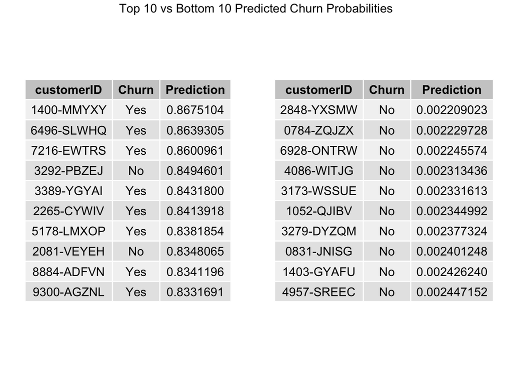

```r
grid.arrange(
  tableGrob(top10, rows = NULL),
  tableGrob(bottom10, rows = NULL),
  ncol = 2,
  top = "Top 10 vs Bottom 10 Predicted Churn Probabilities"
)
```